# Risk Factor Analysis

## Outcome Variable

**Outcome Variable:** y_rate_wtkg

## Predictor Variables

**Intervention Variable:** cleanck

**Adjustment Set:**

- arm
- sex
- W_mage
- meducyrs
- feducyrs
- hhwealth_quart
- W_nrooms
- W_nhh
- W_nchldlt5
- trth2o
- impfloor
- delta_meducyrs
- delta_feducyrs
- delta_hhwealth_quart
- delta_W_nrooms
- delta_W_nhh
- delta_W_nchldlt5
- delta_trth2o
- delta_impfloor

## Stratifying Variables

The analysis was stratified on these variable(s):

- agecat
- studyid
- country

## Data Summary

| agecat | studyid | country | cleanck | n_cell | n | outcome_variable |
| --- | --- | --- | --- | --- | --- | --- |
| 0-3 months | ki0047075b-MAL-ED | PERU | 1 | 1 | 1 | y_rate_wtkg |
| 0-3 months | ki0047075b-MAL-ED | PERU | 0 | 0 | 1 | y_rate_wtkg |
| 0-3 months | ki0047075b-MAL-ED | SOUTH AFRICA | 1 | 2 | 3 | y_rate_wtkg |
| 0-3 months | ki0047075b-MAL-ED | SOUTH AFRICA | 0 | 1 | 3 | y_rate_wtkg |
| 0-3 months | ki1000108-CMC-V-BCS-2002 | INDIA | 1 | 147 | 331 | y_rate_wtkg |
| 0-3 months | ki1000108-CMC-V-BCS-2002 | INDIA | 0 | 184 | 331 | y_rate_wtkg |
| 0-3 months | ki1000108-IRC | INDIA | 1 | 223 | 386 | y_rate_wtkg |
| 0-3 months | ki1000108-IRC | INDIA | 0 | 163 | 386 | y_rate_wtkg |
| 0-3 months | ki1017093b-PROVIDE | BANGLADESH | 1 | 529 | 640 | y_rate_wtkg |
| 0-3 months | ki1017093b-PROVIDE | BANGLADESH | 0 | 111 | 640 | y_rate_wtkg |
| 0-3 months | ki1017093c-NIH-Crypto | BANGLADESH | 1 | 337 | 550 | y_rate_wtkg |
| 0-3 months | ki1017093c-NIH-Crypto | BANGLADESH | 0 | 213 | 550 | y_rate_wtkg |
| 0-3 months | ki1113344-GMS-Nepal | NEPAL | 1 | 7 | 460 | y_rate_wtkg |
| 0-3 months | ki1113344-GMS-Nepal | NEPAL | 0 | 453 | 460 | y_rate_wtkg |
| 3-6 months | ki0047075b-MAL-ED | SOUTH AFRICA | 1 | 1 | 1 | y_rate_wtkg |
| 3-6 months | ki0047075b-MAL-ED | SOUTH AFRICA | 0 | 0 | 1 | y_rate_wtkg |
| 3-6 months | ki1000108-CMC-V-BCS-2002 | INDIA | 1 | 138 | 322 | y_rate_wtkg |
| 3-6 months | ki1000108-CMC-V-BCS-2002 | INDIA | 0 | 184 | 322 | y_rate_wtkg |
| 3-6 months | ki1000108-IRC | INDIA | 1 | 225 | 391 | y_rate_wtkg |
| 3-6 months | ki1000108-IRC | INDIA | 0 | 166 | 391 | y_rate_wtkg |
| 3-6 months | ki1017093b-PROVIDE | BANGLADESH | 1 | 494 | 601 | y_rate_wtkg |
| 3-6 months | ki1017093b-PROVIDE | BANGLADESH | 0 | 107 | 601 | y_rate_wtkg |
| 3-6 months | ki1017093c-NIH-Crypto | BANGLADESH | 1 | 320 | 532 | y_rate_wtkg |
| 3-6 months | ki1017093c-NIH-Crypto | BANGLADESH | 0 | 212 | 532 | y_rate_wtkg |
| 3-6 months | ki1113344-GMS-Nepal | NEPAL | 1 | 6 | 424 | y_rate_wtkg |
| 3-6 months | ki1113344-GMS-Nepal | NEPAL | 0 | 418 | 424 | y_rate_wtkg |
| 6-9 months | ki0047075b-MAL-ED | SOUTH AFRICA | 1 | 1 | 1 | y_rate_wtkg |
| 6-9 months | ki0047075b-MAL-ED | SOUTH AFRICA | 0 | 0 | 1 | y_rate_wtkg |
| 6-9 months | ki1000108-CMC-V-BCS-2002 | INDIA | 1 | 141 | 325 | y_rate_wtkg |
| 6-9 months | ki1000108-CMC-V-BCS-2002 | INDIA | 0 | 184 | 325 | y_rate_wtkg |

[output cut: 68 more lines]

The following strata were considered:

- agecat: 0-3 months, studyid: ki0047075b-MAL-ED, country: PERU
- agecat: 0-3 months, studyid: ki0047075b-MAL-ED, country: SOUTH AFRICA
- agecat: 0-3 months, studyid: ki1000108-CMC-V-BCS-2002, country: INDIA
- agecat: 0-3 months, studyid: ki1000108-IRC, country: INDIA
- agecat: 0-3 months, studyid: ki1017093b-PROVIDE, country: BANGLADESH
- agecat: 0-3 months, studyid: ki1017093c-NIH-Crypto, country: BANGLADESH
- agecat: 0-3 months, studyid: ki1113344-GMS-Nepal, country: NEPAL
- agecat: 12-15 months, studyid: ki0047075b-MAL-ED, country: SOUTH AFRICA
- agecat: 12-15 months, studyid: ki1000108-CMC-V-BCS-2002, country: INDIA
- agecat: 12-15 months, studyid: ki1000108-IRC, country: INDIA
- agecat: 12-15 months, studyid: ki1017093b-PROVIDE, country: BANGLADESH
- agecat: 12-15 months, studyid: ki1017093c-NIH-Crypto, country: BANGLADESH
- agecat: 12-15 months, studyid: ki1113344-GMS-Nepal, country: NEPAL
- agecat: 15-18 months, studyid: ki0047075b-MAL-ED, country: SOUTH AFRICA
- agecat: 15-18 months, studyid: ki1000108-CMC-V-BCS-2002, country: INDIA
- agecat: 15-18 months, studyid: ki1000108-IRC, country: INDIA
- agecat: 15-18 months, studyid: ki1017093b-PROVIDE, country: BANGLADESH
- agecat: 15-18 months, studyid: ki1017093c-NIH-Crypto, country: BANGLADESH
- agecat: 15-18 months, studyid: ki1113344-GMS-Nepal, country: NEPAL
- agecat: 18-21 months, studyid: ki0047075b-MAL-ED, country: SOUTH AFRICA
- agecat: 18-21 months, studyid: ki1000108-CMC-V-BCS-2002, country: INDIA
- agecat: 18-21 months, studyid: ki1000108-IRC, country: INDIA
- agecat: 18-21 months, studyid: ki1017093b-PROVIDE, country: BANGLADESH
- agecat: 18-21 months, studyid: ki1017093c-NIH-Crypto, country: BANGLADESH
- agecat: 18-21 months, studyid: ki1113344-GMS-Nepal, country: NEPAL
- agecat: 21-24 months, studyid: ki0047075b-MAL-ED, country: SOUTH AFRICA
- agecat: 21-24 months, studyid: ki1000108-CMC-V-BCS-2002, country: INDIA
- agecat: 21-24 months, studyid: ki1000108-IRC, country: INDIA
- agecat: 21-24 months, studyid: ki1017093b-PROVIDE, country: BANGLADESH
- agecat: 21-24 months, studyid: ki1017093c-NIH-Crypto, country: BANGLADESH
- agecat: 21-24 months, studyid: ki1113344-GMS-Nepal, country: NEPAL
- agecat: 3-6 months, studyid: ki0047075b-MAL-ED, country: SOUTH AFRICA
- agecat: 3-6 months, studyid: ki1000108-CMC-V-BCS-2002, country: INDIA
- agecat: 3-6 months, studyid: ki1000108-IRC, country: INDIA
- agecat: 3-6 months, studyid: ki1017093b-PROVIDE, country: BANGLADESH
- agecat: 3-6 months, studyid: ki1017093c-NIH-Crypto, country: BANGLADESH
- agecat: 3-6 months, studyid: ki1113344-GMS-Nepal, country: NEPAL
- agecat: 6-9 months, studyid: ki0047075b-MAL-ED, country: SOUTH AFRICA
- agecat: 6-9 months, studyid: ki1000108-CMC-V-BCS-2002, country: INDIA
- agecat: 6-9 months, studyid: ki1000108-IRC, country: INDIA
- agecat: 6-9 months, studyid: ki1017093b-PROVIDE, country: BANGLADESH
- agecat: 6-9 months, studyid: ki1017093c-NIH-Crypto, country: BANGLADESH
- agecat: 6-9 months, studyid: ki1113344-GMS-Nepal, country: NEPAL
- agecat: 9-12 months, studyid: ki0047075b-MAL-ED, country: SOUTH AFRICA
- agecat: 9-12 months, studyid: ki1000108-CMC-V-BCS-2002, country: INDIA
- agecat: 9-12 months, studyid: ki1000108-IRC, country: INDIA
- agecat: 9-12 months, studyid: ki1017093b-PROVIDE, country: BANGLADESH
- agecat: 9-12 months, studyid: ki1017093c-NIH-Crypto, country: BANGLADESH
- agecat: 9-12 months, studyid: ki1113344-GMS-Nepal, country: NEPAL

### Dropped Strata

Some strata were dropped due to rare outcomes:

- agecat: 0-3 months, studyid: ki0047075b-MAL-ED, country: PERU
- agecat: 0-3 months, studyid: ki0047075b-MAL-ED, country: SOUTH AFRICA
- agecat: 3-6 months, studyid: ki0047075b-MAL-ED, country: SOUTH AFRICA
- agecat: 6-9 months, studyid: ki0047075b-MAL-ED, country: SOUTH AFRICA
- agecat: 9-12 months, studyid: ki0047075b-MAL-ED, country: SOUTH AFRICA
- agecat: 12-15 months, studyid: ki0047075b-MAL-ED, country: SOUTH AFRICA
- agecat: 15-18 months, studyid: ki0047075b-MAL-ED, country: SOUTH AFRICA
- agecat: 18-21 months, studyid: ki0047075b-MAL-ED, country: SOUTH AFRICA
- agecat: 21-24 months, studyid: ki0047075b-MAL-ED, country: SOUTH AFRICA
- agecat: 21-24 months, studyid: ki1113344-GMS-Nepal, country: NEPAL

## Methods Detail

We’re interested in the causal parameters $E[Y_a]$ for all values of $a \in \mathcal{A}$. These parameters represent the mean outcome if, possibly contrary to fact, we intervened to set all units to have $A=a$. Under the randomization and positivity assumptions, these are identified by the statistical parameters $\psi_a=E_W[E_{Y|A,W}(Y|A=a,W)]$. In addition, we’re interested in the mean of $Y$, $E[Y]$ under no intervention (the observed mean). We will estimate these parameters by using SuperLearner to fit the relevant likelihood factors – $E_{Y|A,W}(Y|A=a,W)$ and $p(A=a|W)$, and then updating our likelihood fit using a joint TMLE.

For unadjusted analyses ($W=\{\}$), initial likelihoods were estimated using Lrnr_glm to estimate the simple $E(Y|A)$ and Lrnr_mean to estimate $p(A)$. For adjusted analyses, a small library containing Lrnr_glmnet, Lrnr_xgboost, and Lrnr_mean was used.

Having estimated these parameters, we will then use the delta method to estimate relative risks and attributable risks relative to a prespecified baseline level of $A$.

# Results Detail

## Results Plots

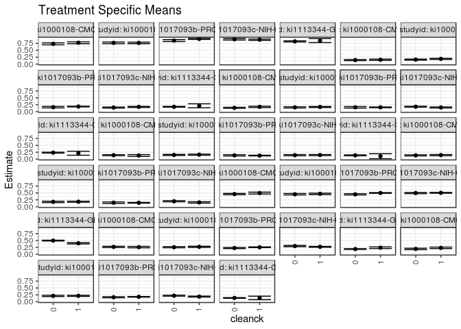

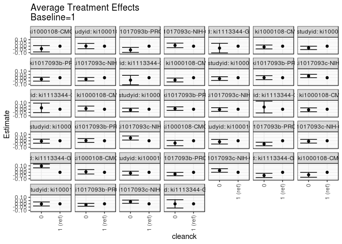

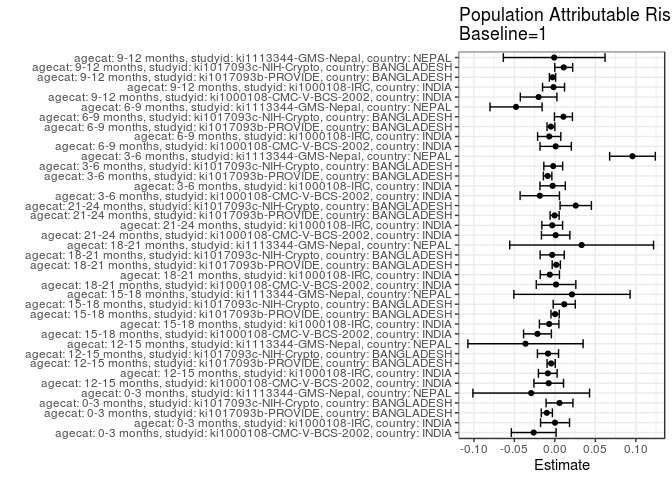

## Results Table

### Parameter: TSM

| agecat | studyid | country | intervention_level | baseline_level | estimate | ci_lower | ci_upper |
| --- | --- | --- | --- | --- | --- | --- | --- |
| 0-3 months | ki1000108-CMC-V-BCS-2002 | INDIA | 1 | NA | 0.7729188 | 0.7392917 | 0.8065458 |
| 0-3 months | ki1000108-CMC-V-BCS-2002 | INDIA | 0 | NA | 0.7332869 | 0.6973919 | 0.7691819 |
| 0-3 months | ki1000108-IRC | INDIA | 1 | NA | 0.7667431 | 0.7394590 | 0.7940272 |
| 0-3 months | ki1000108-IRC | INDIA | 0 | NA | 0.7686968 | 0.7385309 | 0.7988626 |
| 0-3 months | ki1017093b-PROVIDE | BANGLADESH | 1 | NA | 0.9116203 | 0.8954436 | 0.9277970 |
| 0-3 months | ki1017093b-PROVIDE | BANGLADESH | 0 | NA | 0.8533418 | 0.8184833 | 0.8882003 |
| 0-3 months | ki1017093c-NIH-Crypto | BANGLADESH | 1 | NA | 0.8843731 | 0.8599866 | 0.9087596 |
| 0-3 months | ki1017093c-NIH-Crypto | BANGLADESH | 0 | NA | 0.8968339 | 0.8705911 | 0.9230768 |
| 0-3 months | ki1113344-GMS-Nepal | NEPAL | 1 | NA | 0.8517935 | 0.7801961 | 0.9233909 |
| 0-3 months | ki1113344-GMS-Nepal | NEPAL | 0 | NA | 0.8221249 | 0.8038873 | 0.8403626 |
| 3-6 months | ki1000108-CMC-V-BCS-2002 | INDIA | 1 | NA | 0.4937877 | 0.4599105 | 0.5276649 |
| 3-6 months | ki1000108-CMC-V-BCS-2002 | INDIA | 0 | NA | 0.4577074 | 0.4354684 | 0.4799464 |
| 3-6 months | ki1000108-IRC | INDIA | 1 | NA | 0.4667889 | 0.4421093 | 0.4914684 |
| 3-6 months | ki1000108-IRC | INDIA | 0 | NA | 0.4518015 | 0.4262553 | 0.4773478 |
| 3-6 months | ki1017093b-PROVIDE | BANGLADESH | 1 | NA | 0.4980194 | 0.4827487 | 0.5132901 |
| 3-6 months | ki1017093b-PROVIDE | BANGLADESH | 0 | NA | 0.4485617 | 0.4258022 | 0.4713213 |
| 3-6 months | ki1017093c-NIH-Crypto | BANGLADESH | 1 | NA | 0.5032076 | 0.4860842 | 0.5203310 |
| 3-6 months | ki1017093c-NIH-Crypto | BANGLADESH | 0 | NA | 0.4958392 | 0.4730381 | 0.5186403 |
| 3-6 months | ki1113344-GMS-Nepal | NEPAL | 1 | NA | 0.3977899 | 0.3730672 | 0.4225126 |
| 3-6 months | ki1113344-GMS-Nepal | NEPAL | 0 | NA | 0.4950234 | 0.4799980 | 0.5100489 |
| 6-9 months | ki1000108-CMC-V-BCS-2002 | INDIA | 1 | NA | 0.2586172 | 0.2330530 | 0.2841814 |
| 6-9 months | ki1000108-CMC-V-BCS-2002 | INDIA | 0 | NA | 0.2664486 | 0.2439644 | 0.2889328 |
| 6-9 months | ki1000108-IRC | INDIA | 1 | NA | 0.2695950 | 0.2489744 | 0.2902157 |
| 6-9 months | ki1000108-IRC | INDIA | 0 | NA | 0.2562559 | 0.2349784 | 0.2775334 |
| 6-9 months | ki1017093b-PROVIDE | BANGLADESH | 1 | NA | 0.2540233 | 0.2401343 | 0.2679123 |
| 6-9 months | ki1017093b-PROVIDE | BANGLADESH | 0 | NA | 0.2266527 | 0.2050477 | 0.2482578 |
| 6-9 months | ki1017093c-NIH-Crypto | BANGLADESH | 1 | NA | 0.2693651 | 0.2532359 | 0.2854944 |
| 6-9 months | ki1017093c-NIH-Crypto | BANGLADESH | 0 | NA | 0.2978366 | 0.2756927 | 0.3199806 |
| 6-9 months | ki1113344-GMS-Nepal | NEPAL | 1 | NA | 0.2373516 | 0.2071781 | 0.2675251 |
| 6-9 months | ki1113344-GMS-Nepal | NEPAL | 0 | NA | 0.1884564 | 0.1750948 | 0.2018179 |
| 9-12 months | ki1000108-CMC-V-BCS-2002 | INDIA | 1 | NA | 0.2324191 | 0.2050710 | 0.2597671 |
| 9-12 months | ki1000108-CMC-V-BCS-2002 | INDIA | 0 | NA | 0.1934609 | 0.1680958 | 0.2188261 |
| 9-12 months | ki1000108-IRC | INDIA | 1 | NA | 0.2165350 | 0.1967575 | 0.2363126 |
| 9-12 months | ki1000108-IRC | INDIA | 0 | NA | 0.2140649 | 0.1906098 | 0.2375200 |
| 9-12 months | ki1017093b-PROVIDE | BANGLADESH | 1 | NA | 0.1804396 | 0.1697686 | 0.1911105 |
| 9-12 months | ki1017093b-PROVIDE | BANGLADESH | 0 | NA | 0.1651947 | 0.1462152 | 0.1841742 |
| 9-12 months | ki1017093c-NIH-Crypto | BANGLADESH | 1 | NA | 0.1888874 | 0.1725765 | 0.2051983 |
| 9-12 months | ki1017093c-NIH-Crypto | BANGLADESH | 0 | NA | 0.2216487 | 0.2029002 | 0.2403972 |
| 9-12 months | ki1113344-GMS-Nepal | NEPAL | 1 | NA | 0.1404390 | 0.0774489 | 0.2034290 |
| 9-12 months | ki1113344-GMS-Nepal | NEPAL | 0 | NA | 0.1395699 | 0.1259592 | 0.1531806 |
| 12-15 months | ki1000108-CMC-V-BCS-2002 | INDIA | 1 | NA | 0.1580864 | 0.1355582 | 0.1806145 |
| 12-15 months | ki1000108-CMC-V-BCS-2002 | INDIA | 0 | NA | 0.1459009 | 0.1257413 | 0.1660605 |
| 12-15 months | ki1000108-IRC | INDIA | 1 | NA | 0.1895012 | 0.1718629 | 0.2071396 |
| 12-15 months | ki1000108-IRC | INDIA | 0 | NA | 0.1631039 | 0.1438068 | 0.1824009 |
| 12-15 months | ki1017093b-PROVIDE | BANGLADESH | 1 | NA | 0.1846142 | 0.1715899 | 0.1976384 |
| 12-15 months | ki1017093b-PROVIDE | BANGLADESH | 0 | NA | 0.1617410 | 0.1351442 | 0.1883378 |
| 12-15 months | ki1017093c-NIH-Crypto | BANGLADESH | 1 | NA | 0.1719455 | 0.1543025 | 0.1895884 |
| 12-15 months | ki1017093c-NIH-Crypto | BANGLADESH | 0 | NA | 0.1487608 | 0.1286370 | 0.1688846 |
| 12-15 months | ki1113344-GMS-Nepal | NEPAL | 1 | NA | 0.2124379 | 0.1407820 | 0.2840939 |
| 12-15 months | ki1113344-GMS-Nepal | NEPAL | 0 | NA | 0.1754264 | 0.1615923 | 0.1892604 |
| 15-18 months | ki1000108-CMC-V-BCS-2002 | INDIA | 1 | NA | 0.1736633 | 0.1507278 | 0.1965989 |
| 15-18 months | ki1000108-CMC-V-BCS-2002 | INDIA | 0 | NA | 0.1380641 | 0.1184145 | 0.1577137 |
| 15-18 months | ki1000108-IRC | INDIA | 1 | NA | 0.1692288 | 0.1513141 | 0.1871435 |
| 15-18 months | ki1000108-IRC | INDIA | 0 | NA | 0.1553328 | 0.1323224 | 0.1783433 |
| 15-18 months | ki1017093b-PROVIDE | BANGLADESH | 1 | NA | 0.1560639 | 0.1429250 | 0.1692028 |
| 15-18 months | ki1017093b-PROVIDE | BANGLADESH | 0 | NA | 0.1572174 | 0.1295205 | 0.1849142 |
| 15-18 months | ki1017093c-NIH-Crypto | BANGLADESH | 1 | NA | 0.1521469 | 0.1328044 | 0.1714895 |
| 15-18 months | ki1017093c-NIH-Crypto | BANGLADESH | 0 | NA | 0.1787709 | 0.1619305 | 0.1956114 |
| 15-18 months | ki1113344-GMS-Nepal | NEPAL | 1 | NA | 0.2159802 | 0.1441626 | 0.2877979 |
| 15-18 months | ki1113344-GMS-Nepal | NEPAL | 0 | NA | 0.2374486 | 0.2212279 | 0.2536693 |
| 18-21 months | ki1000108-CMC-V-BCS-2002 | INDIA | 1 | NA | 0.1337891 | 0.1015295 | 0.1660488 |
| 18-21 months | ki1000108-CMC-V-BCS-2002 | INDIA | 0 | NA | 0.1448698 | 0.1257203 | 0.1640192 |
| 18-21 months | ki1000108-IRC | INDIA | 1 | NA | 0.1638909 | 0.1446035 | 0.1831783 |
| 18-21 months | ki1000108-IRC | INDIA | 0 | NA | 0.1534450 | 0.1338453 | 0.1730446 |
| 18-21 months | ki1017093b-PROVIDE | BANGLADESH | 1 | NA | 0.1307453 | 0.1176608 | 0.1438299 |
| 18-21 months | ki1017093b-PROVIDE | BANGLADESH | 0 | NA | 0.1399080 | 0.1157904 | 0.1640256 |
| 18-21 months | ki1017093c-NIH-Crypto | BANGLADESH | 1 | NA | 0.1493577 | 0.1313598 | 0.1673556 |
| 18-21 months | ki1017093c-NIH-Crypto | BANGLADESH | 0 | NA | 0.1449852 | 0.1230409 | 0.1669296 |
| 18-21 months | ki1113344-GMS-Nepal | NEPAL | 1 | NA | 0.1069112 | 0.0173514 | 0.1964710 |
| 18-21 months | ki1113344-GMS-Nepal | NEPAL | 0 | NA | 0.1405466 | 0.1237035 | 0.1573898 |
| 21-24 months | ki1000108-CMC-V-BCS-2002 | INDIA | 1 | NA | 0.1474754 | 0.1269500 | 0.1680008 |
| 21-24 months | ki1000108-CMC-V-BCS-2002 | INDIA | 0 | NA | 0.1387038 | 0.1182711 | 0.1591365 |
| 21-24 months | ki1000108-IRC | INDIA | 1 | NA | 0.1808119 | 0.1615769 | 0.2000468 |
| 21-24 months | ki1000108-IRC | INDIA | 0 | NA | 0.1748202 | 0.1509356 | 0.1987047 |
| 21-24 months | ki1017093b-PROVIDE | BANGLADESH | 1 | NA | 0.1422820 | 0.1296886 | 0.1548753 |
| 21-24 months | ki1017093b-PROVIDE | BANGLADESH | 0 | NA | 0.1461599 | 0.1189108 | 0.1734089 |
| 21-24 months | ki1017093c-NIH-Crypto | BANGLADESH | 1 | NA | 0.1550772 | 0.1308743 | 0.1792802 |
| 21-24 months | ki1017093c-NIH-Crypto | BANGLADESH | 0 | NA | 0.1978017 | 0.1778465 | 0.2177570 |

### Parameter: E(Y)

| agecat | studyid | country | intervention_level | baseline_level | estimate | ci_lower | ci_upper |
| --- | --- | --- | --- | --- | --- | --- | --- |
| 0-3 months | ki1000108-CMC-V-BCS-2002 | INDIA | NA | NA | 0.7467559 | 0.7230662 | 0.7704455 |
| 0-3 months | ki1000108-IRC | INDIA | NA | NA | 0.7669350 | 0.7473009 | 0.7865692 |
| 0-3 months | ki1017093b-PROVIDE | BANGLADESH | NA | NA | 0.9016472 | 0.8868914 | 0.9164029 |
| 0-3 months | ki1017093c-NIH-Crypto | BANGLADESH | NA | NA | 0.8901037 | 0.8738687 | 0.9063387 |
| 0-3 months | ki1113344-GMS-Nepal | NEPAL | NA | NA | 0.8225764 | 0.8047018 | 0.8404511 |
| 3-6 months | ki1000108-CMC-V-BCS-2002 | INDIA | NA | NA | 0.4751567 | 0.4562440 | 0.4940693 |
| 3-6 months | ki1000108-IRC | INDIA | NA | NA | 0.4640137 | 0.4462252 | 0.4818022 |
| 3-6 months | ki1017093b-PROVIDE | BANGLADESH | NA | NA | 0.4890611 | 0.4760060 | 0.5021163 |
| 3-6 months | ki1017093c-NIH-Crypto | BANGLADESH | NA | NA | 0.5011716 | 0.4886950 | 0.5136482 |
| 3-6 months | ki1113344-GMS-Nepal | NEPAL | NA | NA | 0.4936475 | 0.4789438 | 0.5083512 |
| 6-9 months | ki1000108-CMC-V-BCS-2002 | INDIA | NA | NA | 0.2595889 | 0.2435057 | 0.2756721 |
| 6-9 months | ki1000108-IRC | INDIA | NA | NA | 0.2625992 | 0.2484830 | 0.2767153 |
| 6-9 months | ki1017093b-PROVIDE | BANGLADESH | NA | NA | 0.2491653 | 0.2371134 | 0.2612172 |
| 6-9 months | ki1017093c-NIH-Crypto | BANGLADESH | NA | NA | 0.2799276 | 0.2681500 | 0.2917053 |
| 6-9 months | ki1113344-GMS-Nepal | NEPAL | NA | NA | 0.1893682 | 0.1763037 | 0.2024326 |
| 9-12 months | ki1000108-CMC-V-BCS-2002 | INDIA | NA | NA | 0.2123308 | 0.1948351 | 0.2298265 |
| 9-12 months | ki1000108-IRC | INDIA | NA | NA | 0.2148825 | 0.2005353 | 0.2292297 |
| 9-12 months | ki1017093b-PROVIDE | BANGLADESH | NA | NA | 0.1775316 | 0.1681968 | 0.1868664 |
| 9-12 months | ki1017093c-NIH-Crypto | BANGLADESH | NA | NA | 0.1997882 | 0.1879938 | 0.2115826 |
| 9-12 months | ki1113344-GMS-Nepal | NEPAL | NA | NA | 0.1395867 | 0.1262232 | 0.1529503 |
| 12-15 months | ki1000108-CMC-V-BCS-2002 | INDIA | NA | NA | 0.1504668 | 0.1366572 | 0.1642764 |
| 12-15 months | ki1000108-IRC | INDIA | NA | NA | 0.1807123 | 0.1677267 | 0.1936978 |
| 12-15 months | ki1017093b-PROVIDE | BANGLADESH | NA | NA | 0.1800324 | 0.1683272 | 0.1917375 |
| 12-15 months | ki1017093c-NIH-Crypto | BANGLADESH | NA | NA | 0.1634289 | 0.1511149 | 0.1757429 |
| 12-15 months | ki1113344-GMS-Nepal | NEPAL | NA | NA | 0.1761486 | 0.1625329 | 0.1897642 |
| 15-18 months | ki1000108-CMC-V-BCS-2002 | INDIA | NA | NA | 0.1521835 | 0.1380291 | 0.1663379 |
| 15-18 months | ki1000108-IRC | INDIA | NA | NA | 0.1621526 | 0.1485252 | 0.1757800 |
| 15-18 months | ki1017093b-PROVIDE | BANGLADESH | NA | NA | 0.1563514 | 0.1445823 | 0.1681205 |
| 15-18 months | ki1017093c-NIH-Crypto | BANGLADESH | NA | NA | 0.1636945 | 0.1517037 | 0.1756852 |
| 15-18 months | ki1113344-GMS-Nepal | NEPAL | NA | NA | 0.2370510 | 0.2211319 | 0.2529701 |
| 18-21 months | ki1000108-CMC-V-BCS-2002 | INDIA | NA | NA | 0.1352327 | 0.1200477 | 0.1504178 |
| 18-21 months | ki1000108-IRC | INDIA | NA | NA | 0.1576598 | 0.1441337 | 0.1711860 |
| 18-21 months | ki1017093b-PROVIDE | BANGLADESH | NA | NA | 0.1324882 | 0.1210438 | 0.1439326 |
| 18-21 months | ki1017093c-NIH-Crypto | BANGLADESH | NA | NA | 0.1460095 | 0.1336664 | 0.1583525 |
| 18-21 months | ki1113344-GMS-Nepal | NEPAL | NA | NA | 0.1399681 | 0.1233886 | 0.1565477 |
| 21-24 months | ki1000108-CMC-V-BCS-2002 | INDIA | NA | NA | 0.1484491 | 0.1344875 | 0.1624106 |
| 21-24 months | ki1000108-IRC | INDIA | NA | NA | 0.1775274 | 0.1635028 | 0.1915520 |
| 21-24 months | ki1017093b-PROVIDE | BANGLADESH | NA | NA | 0.1419705 | 0.1305335 | 0.1534075 |
| 21-24 months | ki1017093c-NIH-Crypto | BANGLADESH | NA | NA | 0.1808389 | 0.1670473 | 0.1946304 |

### Parameter: ATE

| agecat | studyid | country | intervention_level | baseline_level | estimate | ci_lower | ci_upper |
| --- | --- | --- | --- | --- | --- | --- | --- |
| 0-3 months | ki1000108-CMC-V-BCS-2002 | INDIA | 1 | 1 | 0.0000000 | 0.0000000 | 0.0000000 |
| 0-3 months | ki1000108-CMC-V-BCS-2002 | INDIA | 0 | 1 | -0.0396318 | -0.0888163 | 0.0095526 |
| 0-3 months | ki1000108-IRC | INDIA | 1 | 1 | 0.0000000 | 0.0000000 | 0.0000000 |
| 0-3 months | ki1000108-IRC | INDIA | 0 | 1 | 0.0019536 | -0.0387414 | 0.0426487 |
| 0-3 months | ki1017093b-PROVIDE | BANGLADESH | 1 | 1 | 0.0000000 | 0.0000000 | 0.0000000 |
| 0-3 months | ki1017093b-PROVIDE | BANGLADESH | 0 | 1 | -0.0582785 | -0.0967380 | -0.0198190 |
| 0-3 months | ki1017093c-NIH-Crypto | BANGLADESH | 1 | 1 | 0.0000000 | 0.0000000 | 0.0000000 |
| 0-3 months | ki1017093c-NIH-Crypto | BANGLADESH | 0 | 1 | 0.0124608 | -0.0229863 | 0.0479079 |
| 0-3 months | ki1113344-GMS-Nepal | NEPAL | 1 | 1 | 0.0000000 | 0.0000000 | 0.0000000 |
| 0-3 months | ki1113344-GMS-Nepal | NEPAL | 0 | 1 | -0.0296686 | -0.1035523 | 0.0442151 |
| 3-6 months | ki1000108-CMC-V-BCS-2002 | INDIA | 1 | 1 | 0.0000000 | 0.0000000 | 0.0000000 |
| 3-6 months | ki1000108-CMC-V-BCS-2002 | INDIA | 0 | 1 | -0.0360803 | -0.0764596 | 0.0042991 |
| 3-6 months | ki1000108-IRC | INDIA | 1 | 1 | 0.0000000 | 0.0000000 | 0.0000000 |
| 3-6 months | ki1000108-IRC | INDIA | 0 | 1 | -0.0149873 | -0.0505055 | 0.0205308 |
| 3-6 months | ki1017093b-PROVIDE | BANGLADESH | 1 | 1 | 0.0000000 | 0.0000000 | 0.0000000 |
| 3-6 months | ki1017093b-PROVIDE | BANGLADESH | 0 | 1 | -0.0494577 | -0.0769144 | -0.0220009 |
| 3-6 months | ki1017093c-NIH-Crypto | BANGLADESH | 1 | 1 | 0.0000000 | 0.0000000 | 0.0000000 |
| 3-6 months | ki1017093c-NIH-Crypto | BANGLADESH | 0 | 1 | -0.0073684 | -0.0360281 | 0.0212913 |
| 3-6 months | ki1113344-GMS-Nepal | NEPAL | 1 | 1 | 0.0000000 | 0.0000000 | 0.0000000 |
| 3-6 months | ki1113344-GMS-Nepal | NEPAL | 0 | 1 | 0.0972335 | 0.0683030 | 0.1261641 |
| 6-9 months | ki1000108-CMC-V-BCS-2002 | INDIA | 1 | 1 | 0.0000000 | 0.0000000 | 0.0000000 |
| 6-9 months | ki1000108-CMC-V-BCS-2002 | INDIA | 0 | 1 | 0.0078314 | -0.0267656 | 0.0424284 |
| 6-9 months | ki1000108-IRC | INDIA | 1 | 1 | 0.0000000 | 0.0000000 | 0.0000000 |
| 6-9 months | ki1000108-IRC | INDIA | 0 | 1 | -0.0133391 | -0.0435115 | 0.0168333 |
| 6-9 months | ki1017093b-PROVIDE | BANGLADESH | 1 | 1 | 0.0000000 | 0.0000000 | 0.0000000 |
| 6-9 months | ki1017093b-PROVIDE | BANGLADESH | 0 | 1 | -0.0273706 | -0.0529396 | -0.0018015 |
| 6-9 months | ki1017093c-NIH-Crypto | BANGLADESH | 1 | 1 | 0.0000000 | 0.0000000 | 0.0000000 |
| 6-9 months | ki1017093c-NIH-Crypto | BANGLADESH | 0 | 1 | 0.0284715 | 0.0010366 | 0.0559064 |
| 6-9 months | ki1113344-GMS-Nepal | NEPAL | 1 | 1 | 0.0000000 | 0.0000000 | 0.0000000 |
| 6-9 months | ki1113344-GMS-Nepal | NEPAL | 0 | 1 | -0.0488953 | -0.0818949 | -0.0158957 |
| 9-12 months | ki1000108-CMC-V-BCS-2002 | INDIA | 1 | 1 | 0.0000000 | 0.0000000 | 0.0000000 |
| 9-12 months | ki1000108-CMC-V-BCS-2002 | INDIA | 0 | 1 | -0.0389582 | -0.0763262 | -0.0015901 |
| 9-12 months | ki1000108-IRC | INDIA | 1 | 1 | 0.0000000 | 0.0000000 | 0.0000000 |
| 9-12 months | ki1000108-IRC | INDIA | 0 | 1 | -0.0024701 | -0.0335684 | 0.0286282 |
| 9-12 months | ki1017093b-PROVIDE | BANGLADESH | 1 | 1 | 0.0000000 | 0.0000000 | 0.0000000 |
| 9-12 months | ki1017093b-PROVIDE | BANGLADESH | 0 | 1 | -0.0152448 | -0.0371083 | 0.0066186 |
| 9-12 months | ki1017093c-NIH-Crypto | BANGLADESH | 1 | 1 | 0.0000000 | 0.0000000 | 0.0000000 |
| 9-12 months | ki1017093c-NIH-Crypto | BANGLADESH | 0 | 1 | 0.0327613 | 0.0078433 | 0.0576793 |
| 9-12 months | ki1113344-GMS-Nepal | NEPAL | 1 | 1 | 0.0000000 | 0.0000000 | 0.0000000 |
| 9-12 months | ki1113344-GMS-Nepal | NEPAL | 0 | 1 | -0.0008691 | -0.0653129 | 0.0635747 |
| 12-15 months | ki1000108-CMC-V-BCS-2002 | INDIA | 1 | 1 | 0.0000000 | 0.0000000 | 0.0000000 |
| 12-15 months | ki1000108-CMC-V-BCS-2002 | INDIA | 0 | 1 | -0.0121855 | -0.0423423 | 0.0179714 |
| 12-15 months | ki1000108-IRC | INDIA | 1 | 1 | 0.0000000 | 0.0000000 | 0.0000000 |
| 12-15 months | ki1000108-IRC | INDIA | 0 | 1 | -0.0263973 | -0.0526052 | -0.0001895 |
| 12-15 months | ki1017093b-PROVIDE | BANGLADESH | 1 | 1 | 0.0000000 | 0.0000000 | 0.0000000 |
| 12-15 months | ki1017093b-PROVIDE | BANGLADESH | 0 | 1 | -0.0228732 | -0.0525791 | 0.0068327 |
| 12-15 months | ki1017093c-NIH-Crypto | BANGLADESH | 1 | 1 | 0.0000000 | 0.0000000 | 0.0000000 |
| 12-15 months | ki1017093c-NIH-Crypto | BANGLADESH | 0 | 1 | -0.0231847 | -0.0499863 | 0.0036170 |
| 12-15 months | ki1113344-GMS-Nepal | NEPAL | 1 | 1 | 0.0000000 | 0.0000000 | 0.0000000 |
| 12-15 months | ki1113344-GMS-Nepal | NEPAL | 0 | 1 | -0.0370116 | -0.1099908 | 0.0359676 |
| 15-18 months | ki1000108-CMC-V-BCS-2002 | INDIA | 1 | 1 | 0.0000000 | 0.0000000 | 0.0000000 |
| 15-18 months | ki1000108-CMC-V-BCS-2002 | INDIA | 0 | 1 | -0.0355992 | -0.0658462 | -0.0053523 |
| 15-18 months | ki1000108-IRC | INDIA | 1 | 1 | 0.0000000 | 0.0000000 | 0.0000000 |
| 15-18 months | ki1000108-IRC | INDIA | 0 | 1 | -0.0138960 | -0.0431264 | 0.0153345 |
| 15-18 months | ki1017093b-PROVIDE | BANGLADESH | 1 | 1 | 0.0000000 | 0.0000000 | 0.0000000 |
| 15-18 months | ki1017093b-PROVIDE | BANGLADESH | 0 | 1 | 0.0011535 | -0.0296164 | 0.0319233 |
| 15-18 months | ki1017093c-NIH-Crypto | BANGLADESH | 1 | 1 | 0.0000000 | 0.0000000 | 0.0000000 |
| 15-18 months | ki1017093c-NIH-Crypto | BANGLADESH | 0 | 1 | 0.0266240 | 0.0010255 | 0.0522226 |
| 15-18 months | ki1113344-GMS-Nepal | NEPAL | 1 | 1 | 0.0000000 | 0.0000000 | 0.0000000 |
| 15-18 months | ki1113344-GMS-Nepal | NEPAL | 0 | 1 | 0.0214684 | -0.0521583 | 0.0950951 |
| 18-21 months | ki1000108-CMC-V-BCS-2002 | INDIA | 1 | 1 | 0.0000000 | 0.0000000 | 0.0000000 |
| 18-21 months | ki1000108-CMC-V-BCS-2002 | INDIA | 0 | 1 | 0.0110806 | -0.0273138 | 0.0494751 |
| 18-21 months | ki1000108-IRC | INDIA | 1 | 1 | 0.0000000 | 0.0000000 | 0.0000000 |
| 18-21 months | ki1000108-IRC | INDIA | 0 | 1 | -0.0104460 | -0.0380380 | 0.0171461 |
| 18-21 months | ki1017093b-PROVIDE | BANGLADESH | 1 | 1 | 0.0000000 | 0.0000000 | 0.0000000 |
| 18-21 months | ki1017093b-PROVIDE | BANGLADESH | 0 | 1 | 0.0091627 | -0.0185077 | 0.0368330 |
| 18-21 months | ki1017093c-NIH-Crypto | BANGLADESH | 1 | 1 | 0.0000000 | 0.0000000 | 0.0000000 |
| 18-21 months | ki1017093c-NIH-Crypto | BANGLADESH | 0 | 1 | -0.0043724 | -0.0330819 | 0.0243370 |
| 18-21 months | ki1113344-GMS-Nepal | NEPAL | 1 | 1 | 0.0000000 | 0.0000000 | 0.0000000 |
| 18-21 months | ki1113344-GMS-Nepal | NEPAL | 0 | 1 | 0.0336355 | -0.0574944 | 0.1247653 |
| 21-24 months | ki1000108-CMC-V-BCS-2002 | INDIA | 1 | 1 | 0.0000000 | 0.0000000 | 0.0000000 |
| 21-24 months | ki1000108-CMC-V-BCS-2002 | INDIA | 0 | 1 | -0.0087717 | -0.0383171 | 0.0207738 |
| 21-24 months | ki1000108-IRC | INDIA | 1 | 1 | 0.0000000 | 0.0000000 | 0.0000000 |
| 21-24 months | ki1000108-IRC | INDIA | 0 | 1 | -0.0059917 | -0.0371869 | 0.0252035 |
| 21-24 months | ki1017093b-PROVIDE | BANGLADESH | 1 | 1 | 0.0000000 | 0.0000000 | 0.0000000 |
| 21-24 months | ki1017093b-PROVIDE | BANGLADESH | 0 | 1 | 0.0038779 | -0.0262273 | 0.0339831 |
| 21-24 months | ki1017093c-NIH-Crypto | BANGLADESH | 1 | 1 | 0.0000000 | 0.0000000 | 0.0000000 |
| 21-24 months | ki1017093c-NIH-Crypto | BANGLADESH | 0 | 1 | 0.0427245 | 0.0112087 | 0.0742403 |

### Parameter: PAR

| agecat | studyid | country | intervention_level | baseline_level | estimate | ci_lower | ci_upper |
| --- | --- | --- | --- | --- | --- | --- | --- |
| 0-3 months | ki1000108-CMC-V-BCS-2002 | INDIA | 1 | NA | -0.0261629 | -0.0537837 | 0.0014580 |
| 0-3 months | ki1000108-IRC | INDIA | 1 | NA | 0.0001919 | -0.0177114 | 0.0180952 |
| 0-3 months | ki1017093b-PROVIDE | BANGLADESH | 1 | NA | -0.0099731 | -0.0168399 | -0.0031064 |
| 0-3 months | ki1017093c-NIH-Crypto | BANGLADESH | 1 | NA | 0.0057306 | -0.0108589 | 0.0223201 |
| 0-3 months | ki1113344-GMS-Nepal | NEPAL | 1 | NA | -0.0292171 | -0.1012545 | 0.0428203 |
| 3-6 months | ki1000108-CMC-V-BCS-2002 | INDIA | 1 | NA | -0.0186310 | -0.0429308 | 0.0056688 |
| 3-6 months | ki1000108-IRC | INDIA | 1 | NA | -0.0027751 | -0.0184350 | 0.0128847 |
| 3-6 months | ki1017093b-PROVIDE | BANGLADESH | 1 | NA | -0.0089583 | -0.0141958 | -0.0037207 |
| 3-6 months | ki1017093c-NIH-Crypto | BANGLADESH | 1 | NA | -0.0020360 | -0.0136518 | 0.0095798 |
| 3-6 months | ki1113344-GMS-Nepal | NEPAL | 1 | NA | 0.0958576 | 0.0676291 | 0.1240861 |
| 6-9 months | ki1000108-CMC-V-BCS-2002 | INDIA | 1 | NA | 0.0009717 | -0.0184030 | 0.0203464 |
| 6-9 months | ki1000108-IRC | INDIA | 1 | NA | -0.0069959 | -0.0213329 | 0.0073411 |
| 6-9 months | ki1017093b-PROVIDE | BANGLADESH | 1 | NA | -0.0048580 | -0.0096979 | -0.0000180 |
| 6-9 months | ki1017093c-NIH-Crypto | BANGLADESH | 1 | NA | 0.0105625 | -0.0005663 | 0.0216913 |
| 6-9 months | ki1113344-GMS-Nepal | NEPAL | 1 | NA | -0.0479835 | -0.0801642 | -0.0158028 |
| 9-12 months | ki1000108-CMC-V-BCS-2002 | INDIA | 1 | NA | -0.0200883 | -0.0426910 | 0.0025145 |
| 9-12 months | ki1000108-IRC | INDIA | 1 | NA | -0.0016525 | -0.0152256 | 0.0119207 |
| 9-12 months | ki1017093b-PROVIDE | BANGLADESH | 1 | NA | -0.0029080 | -0.0068104 | 0.0009944 |
| 9-12 months | ki1017093c-NIH-Crypto | BANGLADESH | 1 | NA | 0.0109008 | -0.0001670 | 0.0219686 |
| 9-12 months | ki1113344-GMS-Nepal | NEPAL | 1 | NA | -0.0008522 | -0.0636849 | 0.0619804 |
| 12-15 months | ki1000108-CMC-V-BCS-2002 | INDIA | 1 | NA | -0.0076196 | -0.0258923 | 0.0106532 |
| 12-15 months | ki1000108-IRC | INDIA | 1 | NA | -0.0087890 | -0.0203181 | 0.0027402 |
| 12-15 months | ki1017093b-PROVIDE | BANGLADESH | 1 | NA | -0.0045818 | -0.0096455 | 0.0004818 |
| 12-15 months | ki1017093c-NIH-Crypto | BANGLADESH | 1 | NA | -0.0085165 | -0.0215734 | 0.0045404 |
| 12-15 months | ki1113344-GMS-Nepal | NEPAL | 1 | NA | -0.0362894 | -0.1074458 | 0.0348670 |
| 15-18 months | ki1000108-CMC-V-BCS-2002 | INDIA | 1 | NA | -0.0214798 | -0.0386565 | -0.0043031 |
| 15-18 months | ki1000108-IRC | INDIA | 1 | NA | -0.0070762 | -0.0191167 | 0.0049643 |
| 15-18 months | ki1017093b-PROVIDE | BANGLADESH | 1 | NA | 0.0002875 | -0.0048156 | 0.0053907 |
| 15-18 months | ki1017093c-NIH-Crypto | BANGLADESH | 1 | NA | 0.0115475 | -0.0021003 | 0.0251953 |
| 15-18 months | ki1113344-GMS-Nepal | NEPAL | 1 | NA | 0.0210708 | -0.0507157 | 0.0928573 |
| 18-21 months | ki1000108-CMC-V-BCS-2002 | INDIA | 1 | NA | 0.0014436 | -0.0229713 | 0.0258585 |
| 18-21 months | ki1000108-IRC | INDIA | 1 | NA | -0.0062311 | -0.0180877 | 0.0056255 |
| 18-21 months | ki1017093b-PROVIDE | BANGLADESH | 1 | NA | 0.0017428 | -0.0033162 | 0.0068019 |
| 18-21 months | ki1017093c-NIH-Crypto | BANGLADESH | 1 | NA | -0.0033482 | -0.0182598 | 0.0115634 |
| 18-21 months | ki1113344-GMS-Nepal | NEPAL | 1 | NA | 0.0330570 | -0.0557956 | 0.1219096 |
| 21-24 months | ki1000108-CMC-V-BCS-2002 | INDIA | 1 | NA | 0.0009736 | -0.0166028 | 0.0185501 |
| 21-24 months | ki1000108-IRC | INDIA | 1 | NA | -0.0032845 | -0.0160904 | 0.0095214 |
| 21-24 months | ki1017093b-PROVIDE | BANGLADESH | 1 | NA | -0.0003115 | -0.0059141 | 0.0052911 |
| 21-24 months | ki1017093c-NIH-Crypto | BANGLADESH | 1 | NA | 0.0257617 | 0.0064102 | 0.0451131 |